# IRTlib – inlinehelp_view_study_routing_de-deu

## Kommentieren von *Blockly*-Code

Der *IRTLib Editor* unterstützt zwei verschiedene Optionen zur Kommentierung von *Blockl*y-Code.

### Kommentare als *Blockly*-Elemente

Kommentare, die im Ablauf dauerhaft sichtbar sein sollen, können über die Plaette im Abschnitt *Development* hinzugefügt werden:

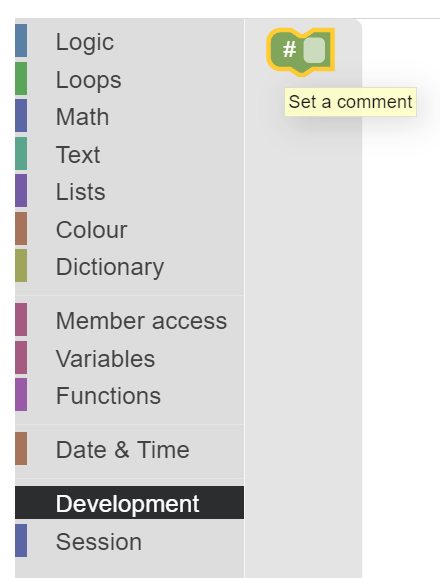

Diese Kommentare können wie Blocky-Operatoren verschoben werden und zeigen einzeiligen Kommentartext.

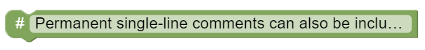

### Ausführliche Kommentare an *Blockly*-Elementen

Für ausführlichere Kommentare kann über das Kontextmenü jeder Block mit einem Kommentar hinzugefügt (und wenn vorhanden gelöscht) werden:

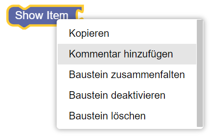

Diese Kommentare können mehrere Zeilen umfassen und werden dargestellt, wenn auf das kleine ?-icon eines Blocks geklickt wurde.

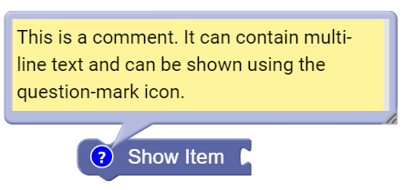

(nach oben)

## Darstellung von *Blockly*-Code

### Entfalten / Zusammenfalten

Große und komplexe Abläufe können im *Blockly*-Editor unter Umständen unübersichtlich werden. Um für eine Betrachtung nicht benötigte *Blockly*-Elemente auszublenden, ohne die Funktion des Ablaufdefinition zu veränern, können Blöcke *zusammengefaltet* werden:

Das wird in folgendem Beispiel illustriert:

- Entfaltete (d.h. vollständige) Darstellung des markierten Blocks:

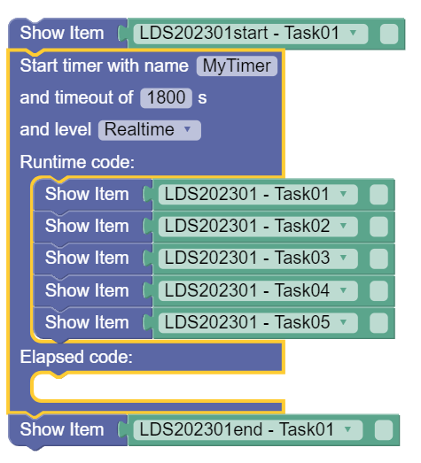

- Option zum *zusammenfalten* des Blocks im Kontextmenü:

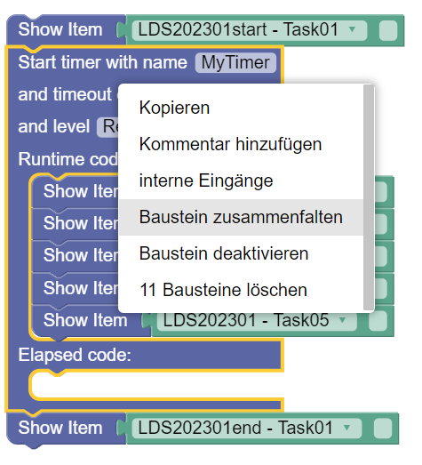

- *Zusammengefaltete* Darstellung des Blocks innerhalb der Ablaufdefinition:

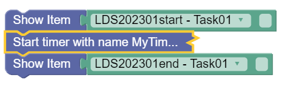

- Option zum *entfalten* des Blocks im Kontextmenü:

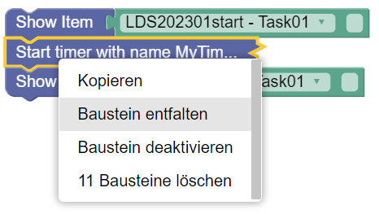

Das *zusammenfalten* / *entfalten* von *Blockly*-Elementen ändert nichts an der Funktion einer Ablaufdefinition und dient nur der übersichtlicheren Anordnung von komplexen Ablaufdefinitionen.

### Deaktivieren / Aktivieren

Der *Blockly*-Editer bietet die Option, *Blockly*-Element statt sie zu Löschen nur zu deaktivieren. Deaktivierte *Blockly*-Elemente bleiben in der Ablaufdefinition enthalten, werden aber nicht ausgeführt.

In folgendem Beispiel ist der Block zum Anzeigen des Tasks 3 deaktiviert, d.h. es werden nur Task 1, 2 und 4 angezeigt:

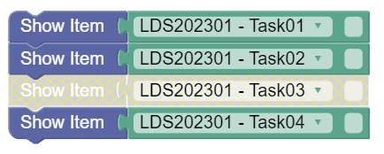

Aktivieren bzw. Deaktivieren von *Blockly*-Elementen erfolgt über das Kontextmenü:

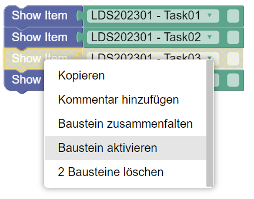

### Internal / External

Einige *Blockly*-Elemente mit *Eingängen* (d.h. Stellen, an denen man weitere Blöcke verbinde kann) erlauben zwischen zwei Darstellungsformen zu wechseln.

- Internal: Die *Eingänge* sind innerhalb der Blöcke angeordnet.
- Exnternal: Die *Eingänge* sind an der Seite der Blöcke angeordnet.

Beide Darstellungsformen sind bzgl. der Funktionalität äquivalent.

### Aufräumen

Im Kontextmenü des *Blockly*-Editors, welches durch Klick in einen leeren Bereich geöffnet werden kann, ist die Funktion *Bausteine aufräumen* enthalten:

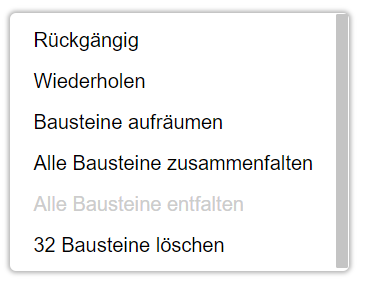

Durch Aufruf von *Bausteine aufäumen* werden alle *Blockly*-Elemente im *Blockly*-Editor vertikal untereinander ausgerichtet.

(nach oben)

## Umsetzung einfacher adaptiver Testdesigns in *Blockly*

### Bedingter Abbruch

Eine Liste von Tasks soll nur solange administriert werden, bis drei mal in Folge eine bestimmte Antwort gegeben wurde:

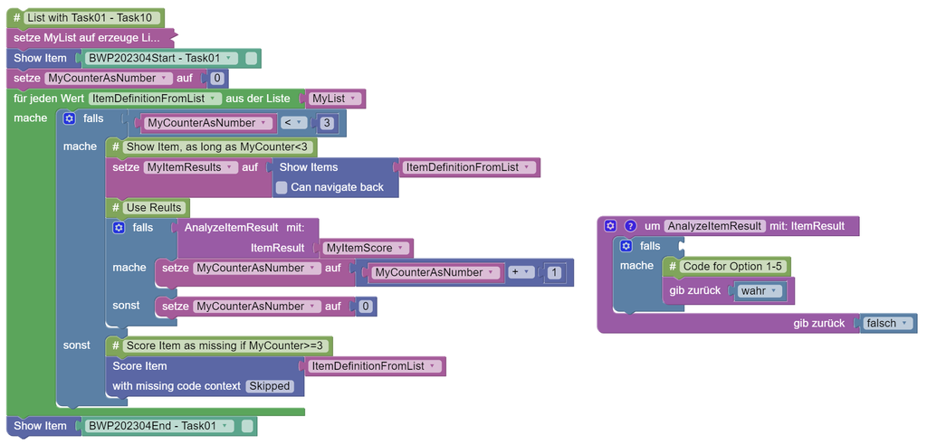

### Multi-Stage Testing (MST)

#### Definition von Stufen

Zusammenstellung von Stufen (*Stages*) aus CBA ItemBuilder *Tasks*:

- Definition von Listen für einzelnen Stufen, jeweils aus konkreten Tasks:

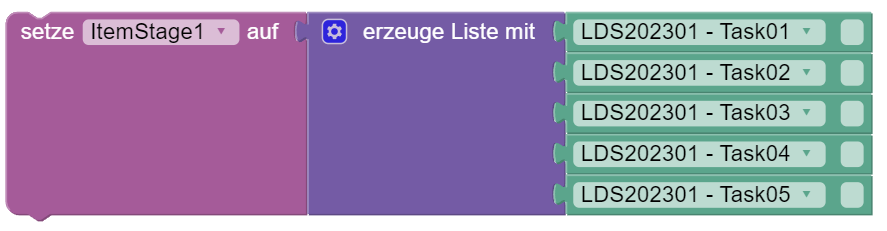

#### Antworten Sammeln

Das Administrieren der *Tasks* einer Stufe erfolgt dann passend zur Definition der Stages.

- Listen für einzelnen Stufen werden vorgelegt durch:

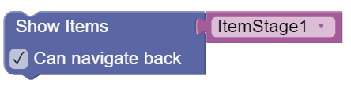

#### Fähigkeit Ermitteln

IRT-basierte Fähigkeitsschätzung aus Antworten erfordert zusätzlich die Definition eines ItemPools.

#### Stufen Verzweigen

(nach oben)

## Adaptives Testen mit IRT und ItemPools (Under Development)

### Computerized Adaptive Testing (CAT)

### Mehrdimensionales Adaptives Teste (MAT)

(nach oben)

## Nutzung von API-Funktionen in *Blockly* (Under Development)

### Kodieren offener Antworten

@SD / TODO: Hier stelle ich zwei Operatoren vor der wie folgt funktionieren:

- Modus
  - Synchron (Es wird gewartet, das Ergebnis kann dann sofort verwendet werden)
  - Asynchron (Es wird nicht gewartet, das Ergebnis wird - wenn vorhanden - nach dem nächsten ShowItem(s) berücksichtigt)
- Name der zu verwendenden API
  - je Item kann das eine andere sein
  - die API muss im Editor/Player registriert sein
- Input
  - Name der API
  - Blockly-Variable mit Ergebnistext
  - Timeout (z.B. 5 Sec.)
  - Default-Wert bei Timeout

(nach oben)